# Transformações de sinais na variável independente

Renato Naville Watanabe

## Transformações

### Deslocamento no tempo

Uma transformação muito importante é o deslocamento no tempo. Essa transformação acontece quando temos dois sinais (tempo contínuo ou discreto) $x$ e $y$ com:

$$y(t) = x(t-T_d)$$

em tempo contínuo, ou

$$y[n] = y[n-N_d]$$

em tempo discreto.

Nesses dois casos, o sinais $x$ e $y$ têm a mesma forma, mas estão deslocados no tempo (atrasados no caso de $T_d$ ou $N_d$ serem positivos e adiantados caso sejam positivos).

#### Exemplo 1

No gráfico abaixo o sinal $x_2(t) = \cos[\pi(t-1.5)]$ é igual o sinal $x_1(t) = \cos(\pi t)$ atrasado de 1,5 segundos ($T_d=1,5$).

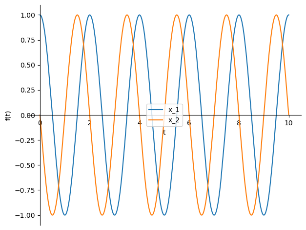

#### Exemplo 2

Para o caso discreto, é mostrado abaixo. O sinal $x_2[n] = \cos\left(\pi \frac{n-3}{N}\right)$ é o sinal $x_1[n] = \cos\left(\pi\frac{n}{N}\right)$ atrasado de 3 instantes.

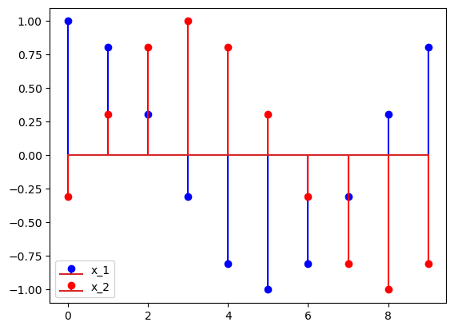

### Reflexão no tempo

A reflexão no tempo é a transformação em que um sinal aparece espelhado em relação à ordenada do gráfico. No gráfico abaixo, o sinal $x_2(t) = x_1(-t)$. É isso que define a reflexão no tempo. Essa transformação irá aparecer numa operação muito importante entre sinais conhecida como convolução.

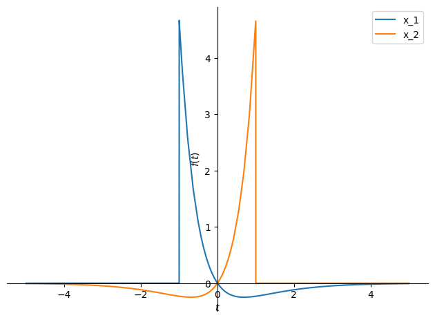

#### Exemplo 4

Abaixo um exemplo de reflexão no tempo para o caso discreto. Note que $x_1[n] = x_2[-n]$.

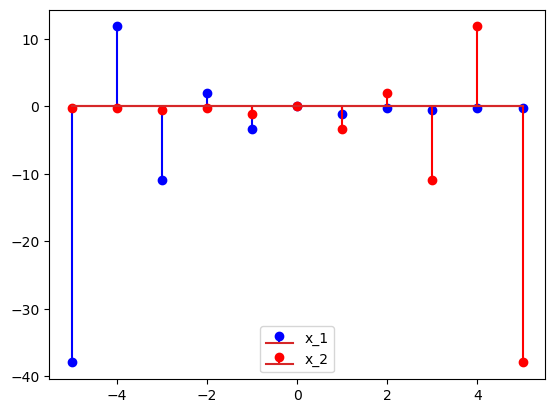

### Mudança de escala

Outra transformação importante é a mudança de escala de um sinal. Ao multiplicar o tempo por uma constante o sinal corre mais rápido (se a constante for maior do que 1) ou mais devagar (se a constante for menor do que 1). Abaixo temos 3 sinais de tempo contínuo. O sinal $x_2(t) = x_1(2t)$. Ele aparece comprimido no tempo. É como se o tempo passou mais rápido para o sinal $x_2(t)$ O sinal $x_3(t) = x_1\left(\frac{t}{2}\right)$. Ele aparece expandido no tempo, como se o tempo passasse mais lentamente para o sinal $x_3(t)$. Esse tipo de transformação é muito usado em aplicativos de mensagem, que possibilitam ouvir uma mensagem de áudio mais rapidamente.

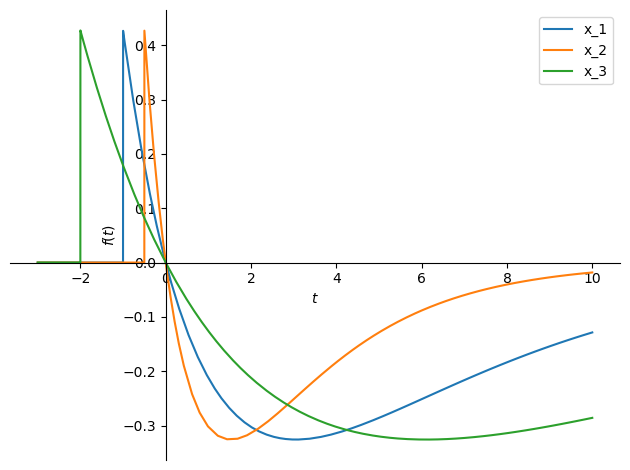

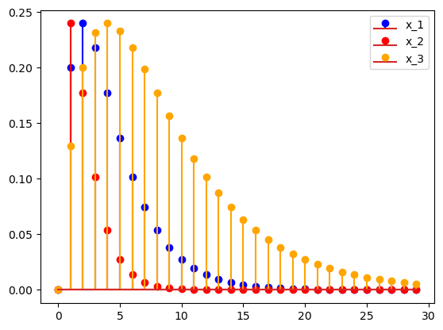

## Simetria par e ímpar

Uma propriedade útil para a análise de sinais é verificar se existe alguma simetria em relação ao tempo. Então são definidas duas simetrias:

### Simetria par:

Acontece se:

$$x(t) = x(-t) $$

no caso de sinais contínuos, e

$$x[n] = x[-n]$$

no caso de sinais de tempo discreto.

#### Exemplo 4

Por exemplo, o sinal cosseno, visto abaixo, tem simetria par. Os instantes negativos têm os mesmos valores dos positivos.

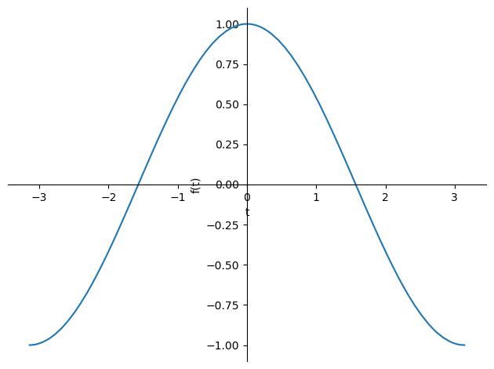

```
<sympy.plotting.plot.Plot at 0x7fdef4f10700>
```

### Simetria ímpar

Acontece se:

$$x(t) = -x(-t) $$

no caso de sinais contínuos, e

$$x[n] = -x[-n]$$

no caso de sinais de tempo discreto.

Note que no caso do sinal ter simetria ímpar, $x(0) = 0$ (já que $x(0) = -x(0)$).

#### Exempo 5

O sinal seno, visto abaixo, tem simetria ímpar. Os instantes negativos têm os valores dos positivos com sinais trocados.

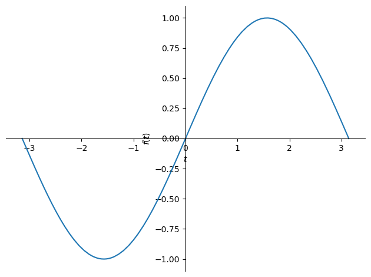

```
<sympy.plotting.plot.Plot at 0x7fba2fc502b0>
```

### Decomposição em sinais pares e ímpares

Qualquer sinal pode ser decomposto em uma parte par e uma parte ímpar. Abaixo as expressões decomposição para tempo contínuo

$Par\{x(t)\} = \frac{x(t)+x(-t)}{2}$

e

$Impar\{x(t)\} = \frac{x(t)-x(-t)}{2}$

#### Exemplo 6

$$Par\{x(t)\} = \frac{e^{-\frac{t}{2}}-e^{-\frac{t}{5}}+e^{\frac{t}{2}}-e^{\frac{t}{5}}}{2}$$$$Impar\{x(t)\} = \frac{e^{-\frac{t}{2}}-e^{-\frac{t}{5}}-e^{\frac{t}{2}}+e^{\frac{t}{5}}}{2}$$

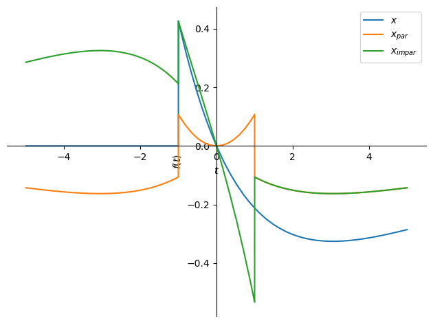

## Sinais periódicos

Um sinal é periódico se existe uma constante $T$ para a qual:

$x(t) = x(t+kT)$

para todo $t$ e para todo $k$ inteiro.

O menor valor de $T$ para o qual a relação acima é verdadeira (note que se se a relação for válida para $T$, será válida para $2T$, $3T$,...) é conhecido como período fundamental $T_0$ (muitas vezes referido simplesmente como período) do sinal $x(t)$.

O grupo de sinais periódicos mais comum e importante (toda a teoria subsequente é baseada nele) é o das senoides:

$$x(t) = \mathrm{sen}(2\pi ft + \theta_0)$$

#### Exemplo 7

Abaixo uma senoide com $f= 3$ e $\theta_0=\frac{\pi}{3}$

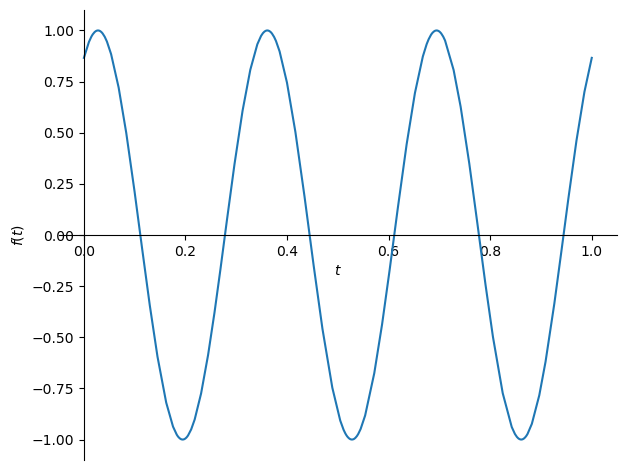

```
<sympy.plotting.plot.Plot at 0x7fba2fd87a00>
```

#### Exemplo 8

```
<StemContainer object of 3 artists>
```

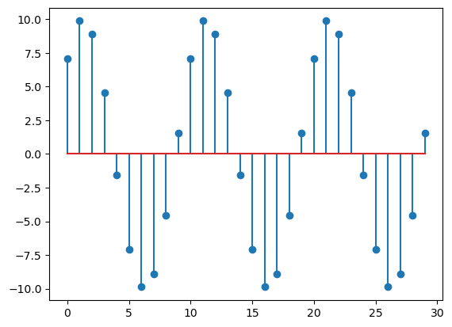

O sinal acima tem período fundamental $N_0 = 10$.

## Referências

- Oppenheim, M. Sistemas e Sinais, 2010
- Ulaby, FT e Yagle, AE, Signals & Systems: Theory and Applications, 2018, ss2.eecs.umich.edu
- Lathi, BP, Sinais e Sistemas Lineares, 2007